# Aplicación de una Red Multicapa en R con muxViz

Preprocesamiento, Recolección y Visualización de Datos Curso 2024/2025

Juan Muelledes Mateos

## Introducción En este documento rmarkdown, vamos a descargar la libreria MuxViz para la creación de Redes Neuronales multicapa, vamos a explorar en profundidad lo que hace esta libreria y vamos a aplicar estos conocimientos creando dos redes neuronales multicapa que trabajen con los datos relativos a los vuelos con origen y/o destino a Estados Unidos de Enero del 2019 y a los de Enero del 2020. En concreto, este trabajo tiene cuatro objetivos fundamentales: Instalación de la librería MuxViz y exploración de las funciones y capacidades de la librería. Aplicación de los conocimientos creando una red neuronal multicapa relacionada con los datos de vuelo de Estados Unidos recopilados en Enero del 2019. Empleo de las funciones otorgadas por MuxViz para realizar un estudio sobre la red multicapa. Creación de una red neuronal multicapa relacionada con los datos de Enero del 2020 y estudio sobre la red para compararla a la de 2019 Finalmente, cabe mencionar que iremos describiendo todo el proceso a modo de poder así ir hablando de las dificultades y problemas que hayamos encontrado, así como de las soluciones empleadas. Y una vez explicado esto, procedemos a la primera sección.

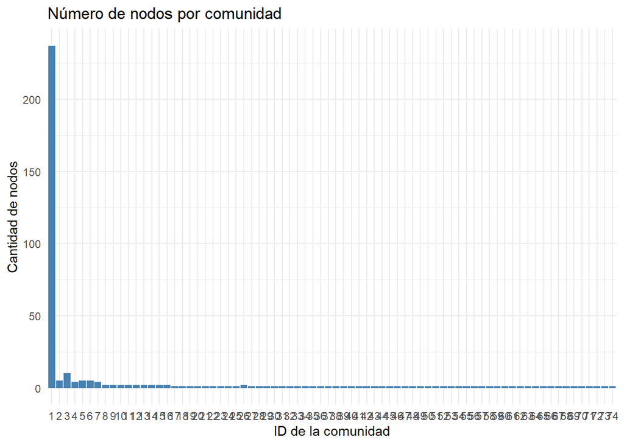

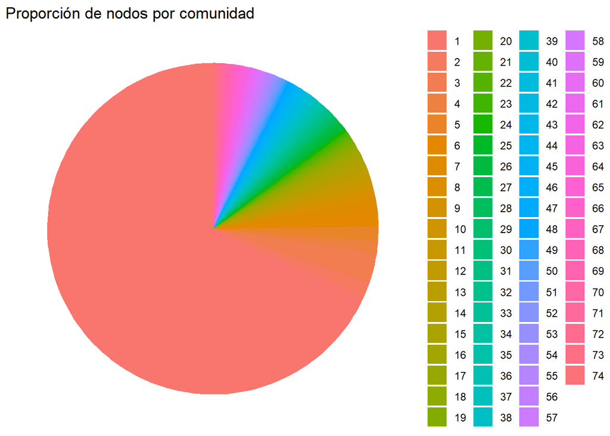

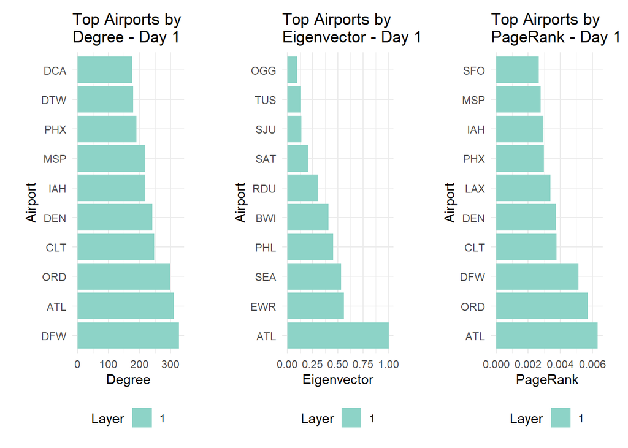

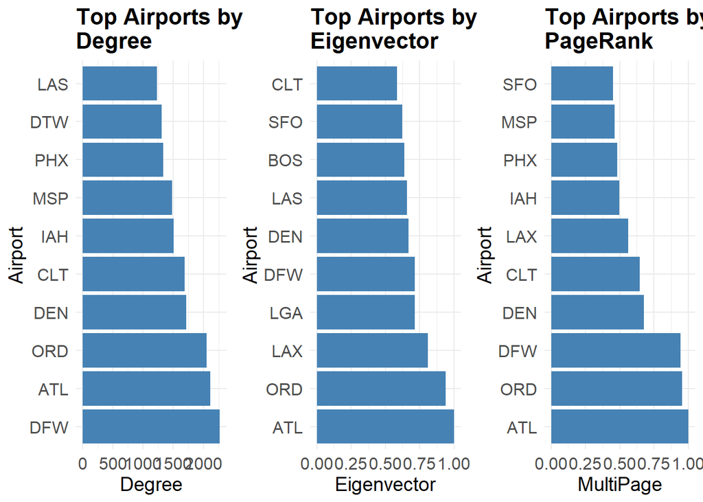

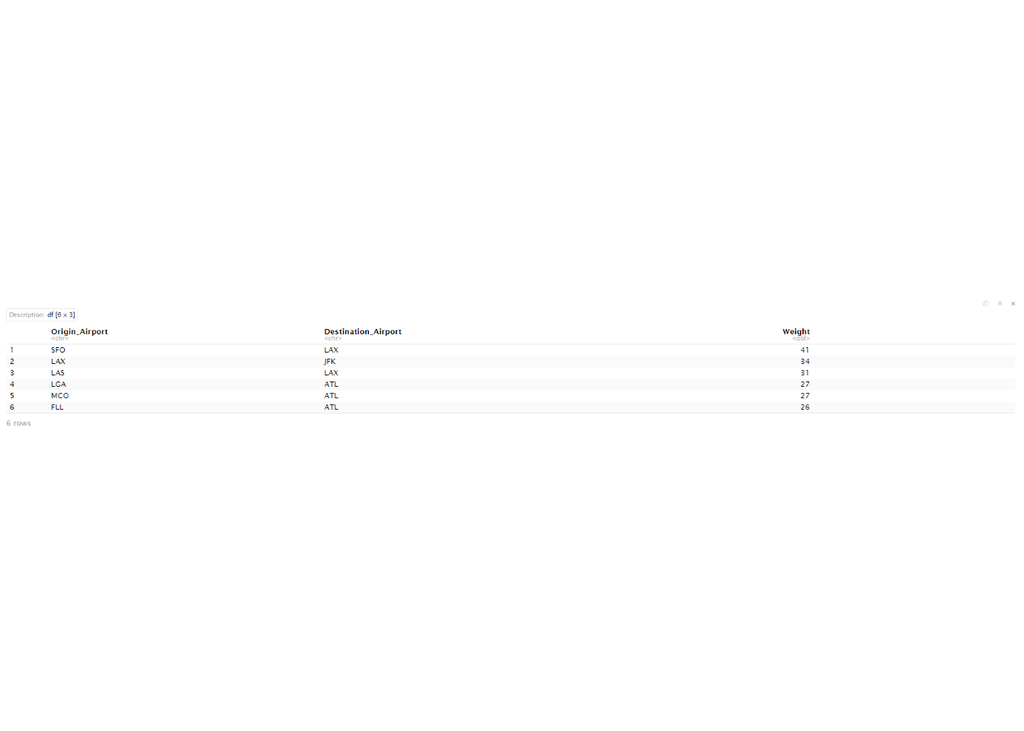

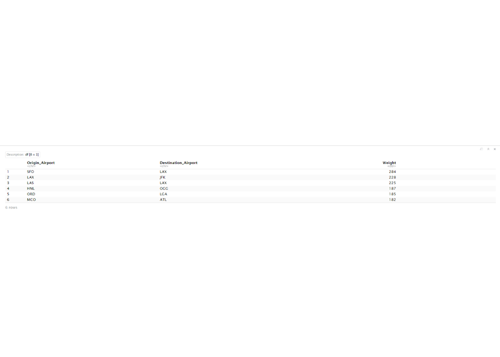

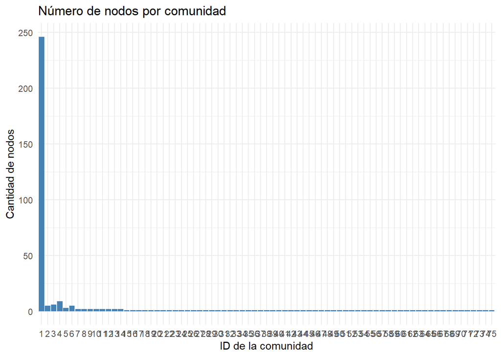

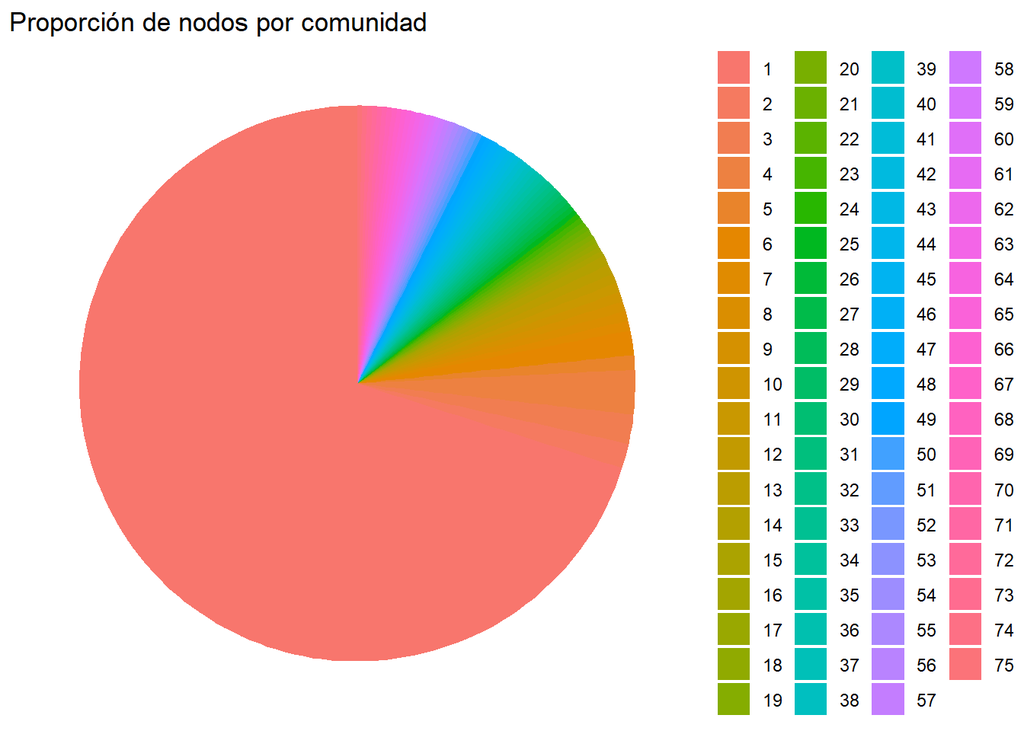

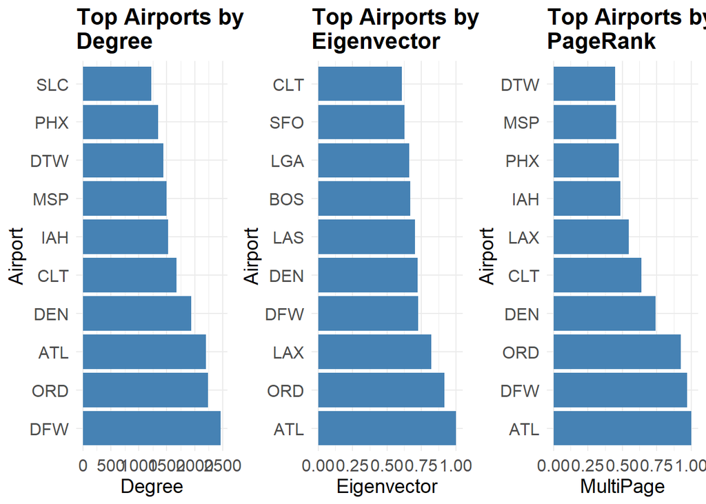

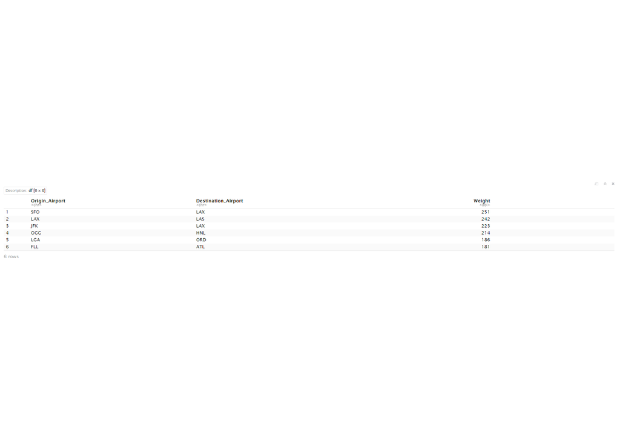